# Chapter 3

**Solving the vampirism detection problem.**

```r
Pr_Positive_Vampire <-0.95
Pr_Positive_Mortal <-0.01
Pr_Vampire <-0.001

Pr_Positive <- Pr_Positive_Vampire*Pr_Vampire+ Pr_Positive_Mortal *(1-Pr_Vampire)

( Pr_Vampire_Positive<-Pr_Positive_Vampire*Pr_Vampire/Pr_Positive) * 100
```

```
[1] 8.683729
```

8.7% chance of actually being a vampire.

**Sampling from a grid-approximate posterior**

A reminder for how to compute the posterior for the globe tossing model, using grid approximation. The posterior here means the probability of p conditional on the data.

```r
p_grid <- seq(from = 0, to = 1, length.out = 1000)   # Some possible values for p.
prob_p <- rep(1, 1000)  # Uniform prior for p. Every "possible value" above has
                        # the same probability
prob_data <- dbinom(6, size = 9, prob = p_grid)  # Probability for getting
                                                 # 6 out of 9, with p = some value in grid

# Bayes
posterior <- prob_data * prob_p
posterior <- posterior / sum(posterior)
```

Taking 10,000 samples from the posterior (with replacement).Individual values of “p” (in p_grid) will appear in our samples in proportion to the posterior plausibility of each value.

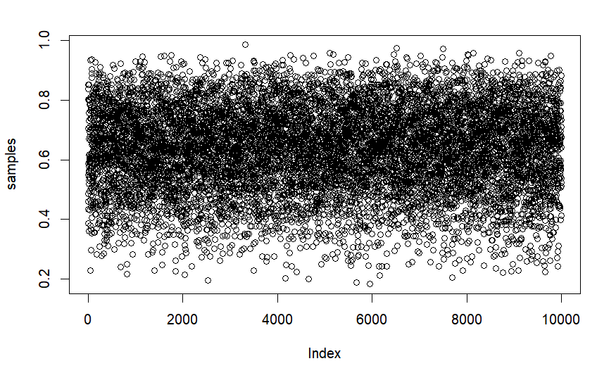

```r
samples <- sample(p_grid, prob = posterior, size = 1e4, replace = TRUE)
plot(samples)
```

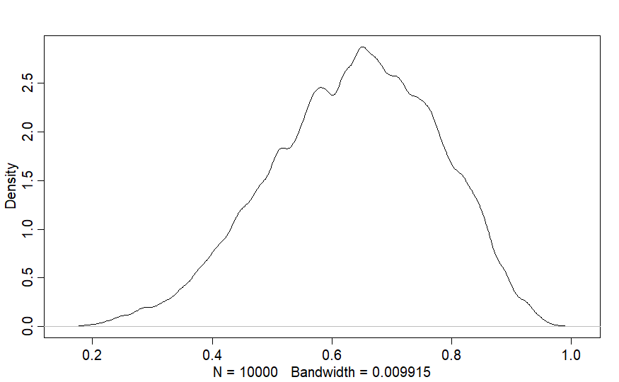

```r
library(rethinking)

# Histogram
dens(samples)
```

```r
# add up posterior probability where p < 0.5
sum(posterior [p_grid < 0.5])
```

```
[1] 0.1718746
```

About 17% of the posterior probability is below 0.5- However, we’ll rarely have a big set of points in the grid to sum over.

Let’s see how to perform the same calculation, using samples from the posterior. All you have to do is add up all the samples below 0.5, but also divide the resulting coount by the total number of samples. In other words, find the frequency of parameter values below 0.5:

```r
# The answer is near to the grid approximation.
sum(samples < 0.5) / 1e4
```

```
[1] 0.1719
```

Using the same approach you can ask how much posterior probability lies between 0.5 and 0.75

```r
sum (samples > 0.5 & samples < 0.75) / 1e4
```

```
[1] 0.6028
```

**Quantiles**

```r
quantile(samples, 0.8)
```

```
      80%
0.7617618
```

```r
quantile(samples, c(0.1, 0.9))
```

```
      10%       90%
0.4483483 0.8158158
```

**Percentiles Intervals**

The quantiles a good job of communicating the shape of a distribution, as long as the distribution isn’t too asymmetrical.

```r
PI(samples, prob = 0.5)
```

```
      25%       75%
0.5425425 0.7397397
```

**Using an asymetrical distribution**

```r
p_grid <- seq(from = 0, to = 1, length.out = 1000)
prob_p <- rep(1, 1000)
prob_data <- dbinom(3, size = 3, prob = p_grid)
posterior <- prob_data * prob_p
posterior <- posterior / sum(posterior)
samples <- sample(p_grid, prob = posterior, size = 1e4, replace = TRUE)
```

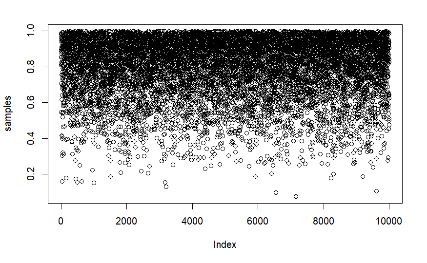

```r
plot(samples)
```

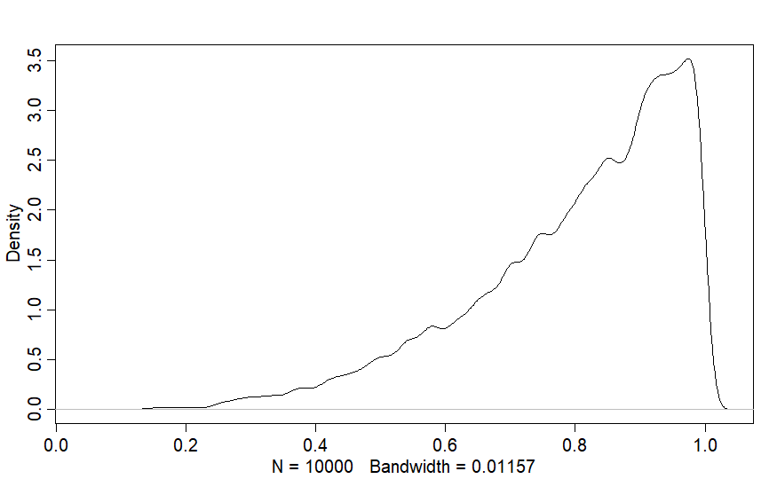

```r
dens(samples)
```

```r
PI(samples, prob = 0.5)
```

```
      25%       75%
0.7057057 0.9289289
```

This last interval assigns 25% of the probability mass above and below the inverval. So it provides the central 50% probability. But in this example, it ends up excluding the most probable parameter values, near p = 1. The percentile interval is misleading.

The **HDPI**: Highest posterior density interval, is the narrowest interval containing the specified probability mass. The interval that best represents the parameter values most consistent with the data then the densest interval does the job.

```r
HPDI(samples, prob = 0.5)
```

```
     |0.5      0.5|
0.8398398 1.0000000
```

HPDI is more computationally intensive and suffers from greater simmulation variance -> it is sensitive to how many samples you draw from the posterior.

**Point estimates.** Given the entire posterior distribution, what value should you report??

Three alternative point estimates:

**Maximimum a posterior (MAP):**

```r
p_grid[which.max(posterior)]
```

```
[1] 1
```

If you instead have samples from the posterior, you can still approximate the same point:

```r
chainmode( samples, adj = 0.01)
```

```
[1] 0.9788942
```

Why not report the posterior mean or median??

```r
mean(samples)
```

```
[1] 0.7991764
```

```r
median(samples)
```

```
[1] 0.8398398
```

One way to go beyind using the entire posterior as the estimate is to choose a “loss function”. Calculating expected loss for any given decisions means using the posterior to average over our uncertainty in the true value.

For the example in the book, the expected loss will be:

```r
sum(posterior * abs(0.5 - p_grid))
```

```
[1] 0.3128752
```

The code computes the weighted average loss, where each loss is weighted by its corresponding posterior probability. A trick for repeating this calculation for every possible decision is:

```r
loss <- sapply(p_grid, function(d) sum(posterior * abs(d - p_grid)))
```

Loss contains a lost of loss values, one for each possible decision, corresponding to values in p_grid. From here, it’s easy to find the parameter value that minimizes the loss:

```r
p_grid[which.min(loss)]
```

```
[1] 0.8408408
```

And this is actually the posterior median!

**Sampling to simulate prediction.**

Dummy data for the water on earth case:

Suppose N = 2, there are three possible overvations: 0 water, 1 water, 2 water- Let’s use p = 0.7 which.

```r
dbinom (0:2, size = 2, prob = 0.7)
```

```
[1] 0.09 0.42 0.49
```

Now we are going to simulate observations, using these probabilities. This is done by sampling fromt he distribution just described above. You could use sample to do this, but R provides convenient sampling functions for all the ordinary probability distributions.:

A single dummy data:

```r
rbinom(1, size = 2, prob = 0.7) # 'r' stands for 'random'
```

```
[1] 0
```

More than one:

```r
rbinom(10, size = 2, prob = 0.7)
```

```
 [1] 2 1 2 2 2 2 1 0 2 2
```

Let’s generate 100,000 dummy observations, just to verify that each value appears in proportion to its likelihood:

```r
dummy_w <- rbinom(1e5, size = 2, prob = 0.7)
table(dummy_w) / 1e5
```

```
dummy_w
      0       1       2
0.08977 0.41921 0.49102
```

Let’s now simmulate 9 tosses:

```r
dummy_w <- rbinom(1e5, size = 9, prob = 0.7)
table(dummy_w) / 1e5
```

```
dummy_w
      1       2       3       4       5       6       7       8       9
0.00039 0.00373 0.02079 0.07392 0.17119 0.26784 0.26821 0.15284 0.04109
```

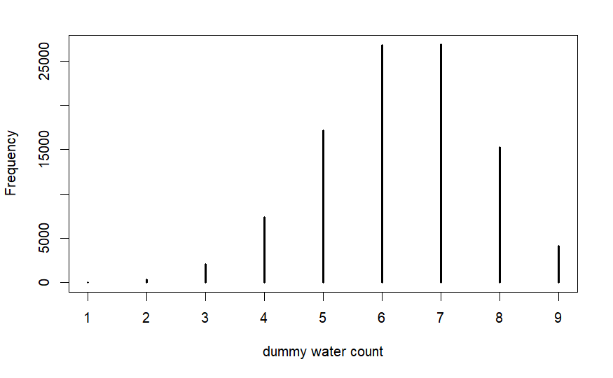

```r
simplehist(dummy_w, xlab = "dummy water count")
```

Most of the time, the expected observation does not contain water in its true proportion… That’s the nature of observation.

**Model checking** 1) ensuring the model fitting worked correctly 2) evaluating the adequacy of a model for some purpose.

The implied predictions of the model are uncertain in two ways, and it’s important to be aware of both.

First, there is observation uncertainty. For any unique values of the parameter p, there is a unique implied pattern of observation that the model expects… There is uncertainty in the predicted observations, because even if you know p with certainty, you won’t know the next globe toss with certainty.

Second, there is uncertainty about p. The posterior distribution over p embodies this uncertainty. And since there is uncertainty about p, there is uncertainty about everything depending upon p.

We’d like to propagate the parameter uncertainty - carry it forward - as we evaluate the implied predictions. All that is required is averaging over the posterior density for p, while computing the predictions. For each possible value of “p” there is an implied distribution of outcomes. So if you ware to compute the sampling distribution of outcomes at each value of p, then you could average all of these prediction distribution together, using the posterior probabilities of each value of p, to get a POSTERIOR PREDICTIVE DISTRIBUTION.

The resulting distribution is for predictions, but it incorporates all of the uncertainty embodied in the posterior distribution for the parameter p. As a result, it is HONEST. Throwing away the uncertainty about the parameters leads to overconfidence in the model.

To simulate predicted observations for a single value of p, say p = 0.6, you can use rbinom to generate random binomial samples.

```r
w <- rbinom(1e4, size = 9, prob = 0.6)
```

This generates 10,000 simulated prediction of 9 globe tosses

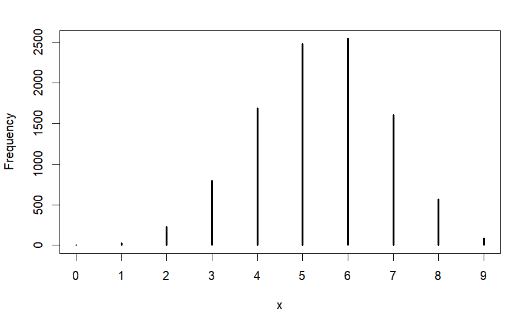

```r
simplehist(w)
```

All you need to propagate parameter uncertainty into these predictions is replace the value 0.6 with samples from the posterior:

```r
w <- rbinom( 1e4, size = 9, prob = samples)
```

‘samples’ is the same list of random samples from the posterior distribution used previously. For each sampled value, a random binomial observation is generated. Since the sampled value appear in proportion to the posterior probabilities, the resulting simulated observations are averaged over the posterior.

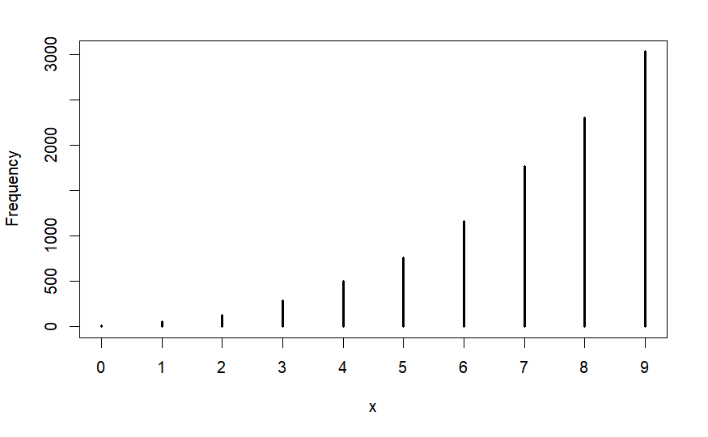

```r
simplehist(w)
```

[figure not shown]

```r
plot(cars)
```